# DS_Capstone

### Model_5.3 XG Boots

Let’s try a third algorithm which am XGBoot

```r
  recipe(formula = Attendance ~ ., data = TRAIN) %>%
  step_nzv(all_predictors())  %>%
    step_impute_median(LaggedAttendance) %>%
  step_novel(all_nominal(), -all_outcomes()) %>%
  step_dummy(all_nominal(), -all_outcomes(), one_hot = TRUE) -> xgboost_recipe_B
 #XGBoot prefers one hot than dummy variables



stopping_spec_B <-
  boost_tree(
    trees = 500,
    mtry = tune(),
    learn_rate = tune(),
    stop_iter = tune()
  ) %>%
  set_engine("xgboost", validation = 0.2) %>%
  set_mode("regression")

stopping_grid_B <-
  grid_latin_hypercube(
    mtry(range = c(5L, 17L)), ## depends on number of columns in data
    learn_rate(range = c(-5, -1)), ## keep pretty big
    stop_iter(range = c(10L, 50L)), ## bigger than default
    size = 10
  )
# Where 17 is the total number of features


# Now we can put these together in a workflow and tune across the grid of parameters and our resamples.

early_stop_wf_B <- workflow(xgboost_recipe_B, stopping_spec_B)

doParallel::registerDoParallel()
set.seed(345)
stopping_rs_B <- tune_grid(
  early_stop_wf_B,
  FOLDS_B,
  grid = stopping_grid_B,
)


show_best(stopping_rs_B, metric = "rmse")
```

```
## # A tibble: 5 x 9
##    mtry learn_rate stop_iter .metric .estimator  mean     n std_err .config
##   <int>      <dbl>     <int> <chr>   <chr>      <dbl> <int>   <dbl> <chr>
## 1    12    0.0315         19 rmse    standard   0.759    25 0.00569 Preprocesso~
## 2    17    0.0103         31 rmse    standard   0.769    25 0.00504 Preprocesso~
## 3     8    0.0931         34 rmse    standard   0.771    25 0.00538 Preprocesso~
## 4     6    0.00311        41 rmse    standard   1.87     25 0.00608 Preprocesso~
## 5     7    0.00125        46 rmse    standard   4.14     25 0.00531 Preprocesso~
```

```r
show_best(stopping_rs_B, metric = "rsq")
```

```
## # A tibble: 5 x 9
##    mtry learn_rate stop_iter .metric .estimator  mean     n std_err .config
##   <int>      <dbl>     <int> <chr>   <chr>      <dbl> <int>   <dbl> <chr>
## 1    12    0.0315         19 rsq     standard   0.738    25 0.00363 Preprocesso~
## 2    17    0.0103         31 rsq     standard   0.736    25 0.00354 Preprocesso~
## 3     8    0.0931         34 rsq     standard   0.730    25 0.00372 Preprocesso~
## 4     6    0.00311        41 rsq     standard   0.670    25 0.00401 Preprocesso~
## 5     7    0.00125        46 rsq     standard   0.644    25 0.00483 Preprocesso~
```

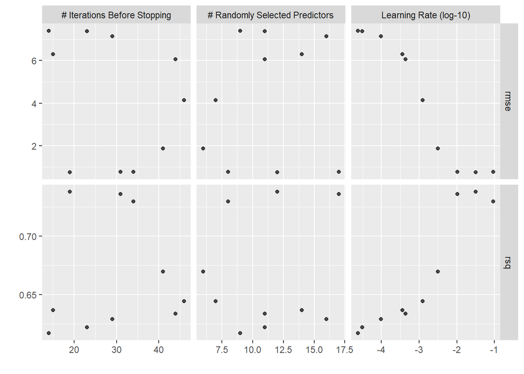

```r
autoplot(stopping_rs_B)
```

```r
#Select the hyperparameters  of the one who has the  minimum rmse
final_XG_B <- early_stop_wf_B %>%
  finalize_workflow(select_best(stopping_rs_B, metric = "rmse"))

fit_XG_B <- last_fit(final_XG_B, SPLIT)
fit_XG_B
```

```
## # Resampling results
## # Manual resampling
## # A tibble: 1 x 6
##   splits             id               .metrics   .notes   .predictions .workflow
##   <list>             <chr>            <list>     <list>   <list>       <list>
## 1 <split [1392/467]> train/test split <tibble [~ <tibble~ <tibble [46~ <workflo~
```

```r
collect_metrics(fit_XG_B)
```

```
## # A tibble: 2 x 4
##   .metric .estimator .estimate .config
##   <chr>   <chr>          <dbl> <chr>
## 1 rmse    standard       0.722 Preprocessor1_Model1
## 2 rsq     standard       0.743 Preprocessor1_Model1
```

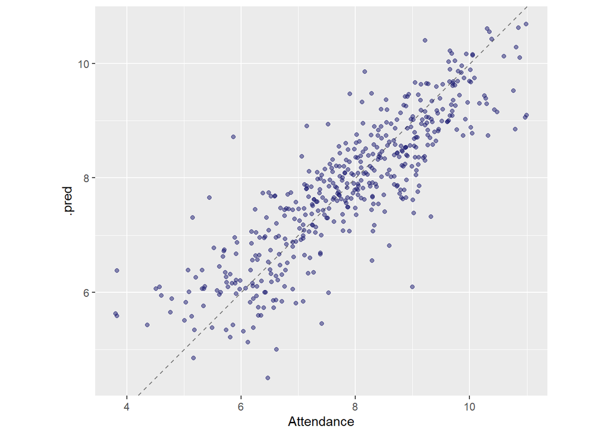

```r
collect_predictions(fit_XG_B) %>%
  ggplot(aes(Attendance, .pred)) +
  geom_abline(lty = 2, color = "gray50") +
  geom_point(alpha = 0.5, color = "midnightblue") +
  coord_fixed()
```

```r
# VIP
imp_spec_XG_B <- stopping_spec_B %>%
  finalize_model(select_best(stopping_rs_B)) %>%
  set_engine("xgboost", importance = "permutation")
workflow() %>%
  add_recipe(xgboost_recipe_B) %>%
  add_model(imp_spec_XG_B) %>%
  fit(TRAIN) %>%
  pull_workflow_fit() %>%
  vip(aesthetics = list(alpha = 0.8, fill = "midnightblue"))
```

[output not shown]

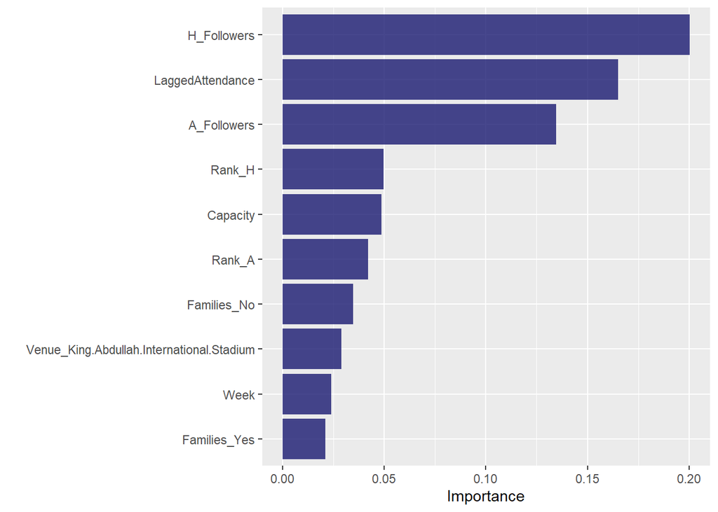

### Model_5.4 KNN

Let’s try a forth algorithm which is KNN

```r
#Recipe
  recipe(formula = Attendance ~ ., data = TRAIN) %>%
  step_zv(all_predictors()) %>%
    step_impute_median(LaggedAttendance) %>%
  step_normalize(all_predictors(), -all_nominal()) %>%
  step_novel(all_nominal(), -all_outcomes()) %>%
  step_dummy(all_nominal(), -all_outcomes()) -> knn_recipe_B
#Specification
 nearest_neighbor(neighbors = tune()) %>%
  set_engine("kknn") %>%
  set_mode("regression") -> knn_spec_B

 # Workflow
  workflow() %>%
  add_recipe(knn_recipe) %>%
  add_model(knn_spec) -> knn_workflow_B

  # Create grid of hyperparameter values
knn_grid_B <- expand.grid(neighbors = seq(1, 100, by = 4))

knn_tune_B <-
  tune_race_anova(knn_workflow_B,
                  resamples = FOLDS_B,
                  grid = knn_grid_B,
                  )

show_best(knn_tune_B, metric = "rmse")
```

```
## # A tibble: 3 x 7
##   neighbors .metric .estimator  mean     n std_err .config
##       <dbl> <chr>   <chr>      <dbl> <int>   <dbl> <chr>
## 1        21 rmse    standard   0.944    25 0.00760 Preprocessor1_Model06
## 2        25 rmse    standard   0.945    25 0.00752 Preprocessor1_Model07
## 3        17 rmse    standard   0.946    25 0.00779 Preprocessor1_Model05
```

```r
show_best(knn_tune_B, metric = "rsq")
```

```
## # A tibble: 3 x 7
##   neighbors .metric .estimator  mean     n std_err .config
##       <dbl> <chr>   <chr>      <dbl> <int>   <dbl> <chr>
## 1        25 rsq     standard   0.595    25 0.00524 Preprocessor1_Model07
## 2        21 rsq     standard   0.595    25 0.00518 Preprocessor1_Model06
## 3        17 rsq     standard   0.592    25 0.00523 Preprocessor1_Model05
```

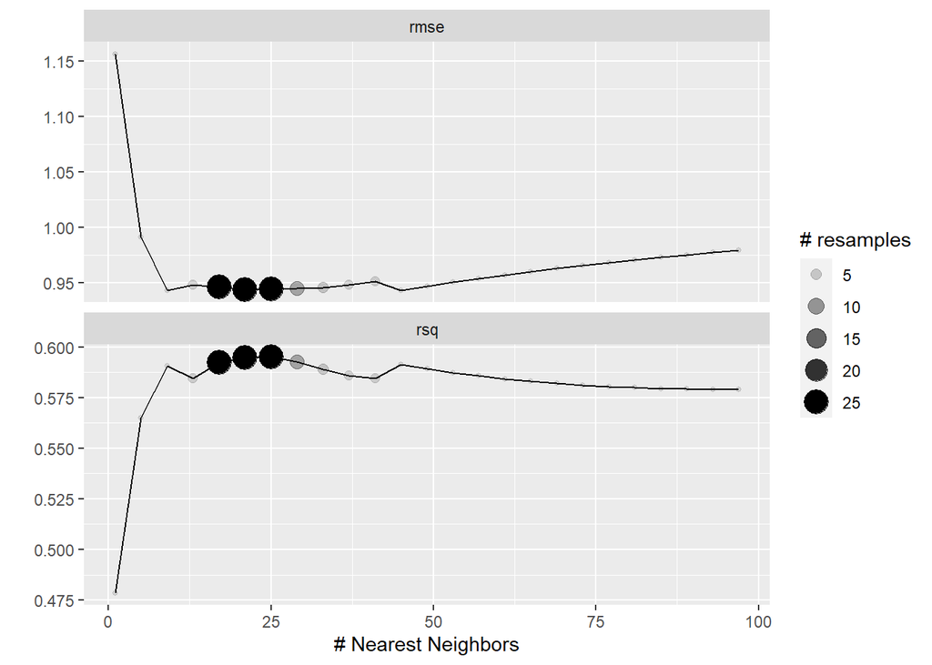

```r
autoplot(knn_tune_B)
```

```r
#Select the hyperparameters  of the one who has the  minimum rmse
final_knn_B <- knn_workflow_B %>%
  finalize_workflow(select_best(knn_tune, metric = "rmse"))

fit_knn_B <- last_fit(final_knn_B, SPLIT)
fit_knn_B
```

```
## # Resampling results
## # Manual resampling
## # A tibble: 1 x 6
##   splits             id               .metrics   .notes   .predictions .workflow
##   <list>             <chr>            <list>     <list>   <list>       <list>
## 1 <split [1392/467]> train/test split <tibble [~ <tibble~ <tibble [46~ <workflo~
```

```r
collect_metrics(fit_knn_B)
```

```
## # A tibble: 2 x 4
##   .metric .estimator .estimate .config
##   <chr>   <chr>          <dbl> <chr>
## 1 rmse    standard       0.849 Preprocessor1_Model1
## 2 rsq     standard       0.645 Preprocessor1_Model1
```

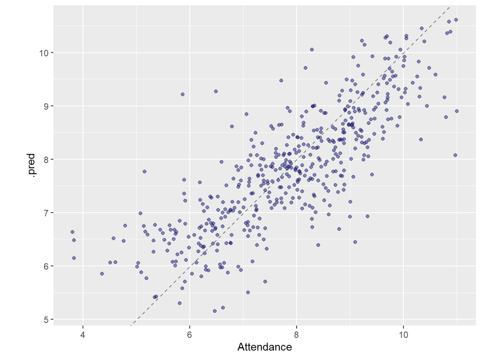

```r
collect_predictions(fit_knn_B) %>%
  ggplot(aes(Attendance, .pred)) +
  geom_abline(lty = 2, color = "gray50") +
  geom_point(alpha = 0.5, color = "midnightblue") +
  coord_fixed()
```

```r
# VIP
imp_spec_knn_B <- knn_spec_B %>%
  finalize_model(select_best(knn_tune_B, metric = "rmse")) %>%
  set_engine("kknn", importance = "permutation")
```

Similar reulsts to the cv folds resampling but with higher differences of the Loss Function

# **Part6: Conclusion**

According to the introduction, predicting the attendance of an SPL game have many perks. For that purpose,four algorithms which are KNN, Random Forest, XGBoost, and GLMNET have been tuned and used to build models with both cv fold and bootstrapping resampling methods. All of them have accepted RSME values (not high). However, it is noticed that all of them tend to perform badly with law attendance. Moreover, unfortunately in all of them the training set’s RMSE is higher than the one of the testing set. This is most probability due to a couple of reasons: 1- Having a small dataset 2- The assumption of having a constant twitter followers (H & A) since they appeared in most the models as the top important features

# **Part7: Limitations & Problems**

- Small Dataset
- Not well-rounded features considered
- Using a rough assumption
- Take much time to run the code since it consists od 8 models, which make it try things.

# **Part8: Future Development**

There are some opportunities to enhance the models via:

- Adding more matches to solve the problem of having small dataset
- Adding Price Tickets as a feature
- Updating Twitter Followers after each transfer window (Twice a season)
- Adding the Distance between the venue and the downtown as a feature
- Adding the total points after each round as a feature

Also remember that this project can be deployed with any soccer league not just the SPL